# Case example 3: Find the effects of a treatment on gene expression

In this tutorial we will expand the analysis done in case example 2 with a more in-depth exploration of differential gene expression.

First, let’s recap the experimental design. In this case we have samples of epididymal white adipose tissue from lean and obese mice, which two biological replicates for each condition:

| Sample | Replica | Condition |
| --- | --- | --- |
| GSE160729_HDF_1 | 1 | High.Fat.Diet |
| GSE160729_HDF_2 | 2 | High.Fat.Diet |
| GSE160729_LDF_1 | 1 | Low.Fat.Diet |
| GSE160729_LDF_2 | 2 | Low.Fat.Diet |

In **Case example 2** we proceeded to filter out lower quality cells in each sample and integrate them into a single dataset. This integration process helped us mitigate the effects of technical and biological variation, making it possible to classify the cells by the next largest factor influencing gene expression: **cell type**:

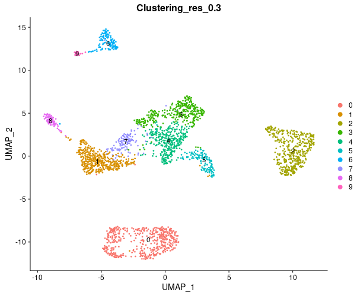

Once the cells were classified in different clusters, we could calculate differential gene expression to define what makes each cluster different from the rest, and whith that, assign a cell type identity to the clusters:

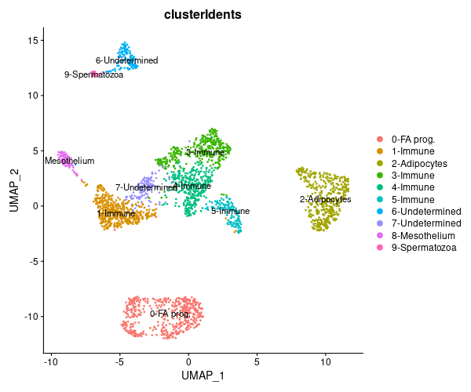

Here we will try to find cluster-specific changes in gene in gene expression caused by the different conditions of the samples, in this case, the diet fed to the mice.

### Conditional differential expression

When testing conditional differential gene expression, our goal is to find the effect of a factor, in this case, high or low fat diets, in gene expression *given a set condition*, which here is the class (or cluster) assigned to each cell.

*—“Why testing each cluster separately? Wouldn’t it be preferable to have a larger sample size using all cells?”*

In most situations the datasets we’re working with will have an umbalanced distribution of cells of each type. We could test differential expression using only the treatment or condition as a grouping variable, but we would run into several risks:

- The most abundant cell types would be over-represented, obscuring the effects of the treatment on less common cell types.
- Even if we had a similar number of cells in each type, we’d still be swaying the results towards gene expression changes that occur accross cell types, and thus possibly missing cell-type specific reactions to the treatment or condition examined.

To calculate differential expression, select *Condition* as the first grouping variable, and then *Clustering_res_0.3* as the secondary grouping variable. Select *Conditional* as the analysis mode and choose what condition will be the foregroud (in this example we have chosen “*HDF*”, or *High Fat Diet*). For now, we’ll leave the rest of the parameters with their default values.

Here is a brief summary of the results:

| Comparison | Cells in Foreground | Cells in Background | Total DEG | Up regulated Genes | Down regulated Genes |
| --- | --- | --- | --- | --- | --- |
| HFD - 0 VS LFD - 0 | 203 | 289 | 176 | 64 | 112 |
| HFD - 1 VS LFD - 1 | 401 | 47 | 73 | 41 | 32 |
| HFD - 2 VS LFD - 2 | 103 | 327 | 258 | 179 | 79 |
| HFD - 3 VS LFD - 3 | 265 | 90 | 205 | 111 | 94 |
| HFD - 4 VS LFD - 4 | 203 | 140 | 127 | 64 | 63 |
| HFD - 5 VS LFD - 5 | 72 | 60 | 74 | 50 | 24 |
| HFD - 6 VS LFD - 6 | 45 | 81 | 93 | 50 | 43 |
| HFD - 7 VS LFD - 7 | 59 | 62 | 44 | 32 | 12 |
| HFD - 8 VS LFD - 8 | 23 | 57 | 19 | 16 | 3 |
| HFD - 9 VS LFD - 9 | 14 | 15 | NA | NA | NA |

As you can see the first difference compared to the differential expression analysis done in Case Example 2 is that we are getting significantly fewer DE genes. On one hand, we are comparing smaller groups of cells, and on the other, the two groups that we are comparing belong to the same cluster, so they are more similar to each other.

Often times when calculating conditional differential expression we will find cases like that of cluster 9, where one or both conditions can’t reach the threshold of *Minimum number of cells*, and thus they are skipped in the analysis. This parameter could be set lower so cluster 9 is also analyzed, but keep in mind that with small groups of cells, even if a few genes are significantly altered, we should consider if the finding is not only statistically significant, but also question whether it’s biologically relevant and the effect could be replicated.

### Finding meaning in differential expression: altered pathways

Differential expression results will return which genes are significantly up or down-regulated, but more often than not, to extract useful information some further annotation work will be required. Even more with datasets like the one being used in this tutorial, since genes are identified using [ENSEMBLE Gene IDs](https://www.ensembl.org/info/genome/stable_ids/index.html), and this nomenclature has many advantages, but memorability ain’t one of them.

We can take advantage of resources like [MSigDB](https://www.gsea-msigdb.org/gsea/msigdb/index.jsp), in which many other databases have been compiled into convinient, easy to use, lists of genes linked to a particular annotation term, like:

- Genes connected to a particular biological function.
- Targets of X transcription factor.
- Genes up-regulated in by Y treatment in Z paper.

For this app we have chosen to incorporate some of the most stable and easy to interpret collections of MSigDB, the gene sets corresponding to molecular pathway databases: REACTOME, KEGG, Biocarta, PID, and WikiPathways. With this gene sets we will perform an *Enrichment Analysis*, with the intention to **find molecular pathways with more differentially expressed genes that we would expect by chance**.

In the Altered Pathways tab we can restrict the analysis to only one or a few of the available databases, as well as test enrichment only on some of the Differential Expression results. In this case, we’ll use all the databases and all clusters available (0 to 8). With the results of the differential expression analysis we have just done, here’s the summary of the *Altered Pathways Analysis*:

| Comparison | Mode of DE analysis | Cells in foreground | Cells in background | Total expressed genes | Differentially expressed genes | Pathways examined | Pathways enriched in DEGs |
| --- | --- | --- | --- | --- | --- | --- | --- |
| HFD - 0 VS LFD - 0 | Conditional | 203 | 289 | 1073 | 176 | 287 | 4 |
| HFD - 1 VS LFD - 1 | Conditional | 401 | 47 | 540 | 73 | 60 | 4 |
| HFD - 2 VS LFD - 2 | Conditional | 103 | 327 | 2113 | 258 | 603 | 6 |
| HFD - 3 VS LFD - 3 | Conditional | 265 | 90 | 1240 | 205 | 338 | 2 |
| HFD - 4 VS LFD - 4 | Conditional | 203 | 140 | 808 | 127 | 142 | 1 |
| HFD - 5 VS LFD - 5 | Conditional | 72 | 60 | 2481 | 74 | 172 | 3 |
| HFD - 6 VS LFD - 6 | Conditional | 45 | 81 | 863 | 93 | 102 | 0 |
| HFD - 7 VS LFD - 7 | Conditional | 59 | 62 | 620 | 44 | 59 | 1 |
| HFD - 8 VS LFD - 8 | Conditional | 23 | 57 | 1030 | 19 | 65 | 2 |
| HFD - 9 VS LFD - 9 | Conditional | 14 | 15 | 1237 | 0 | NA | NA |

We can see a few molecular pathways in each cluster that contain enough differentially expressed genes. It’s also wort pointing out the number of genes that are “expressed” in each cluster -that is, genes that have been detected in a considerable percentage of the cluster-. We can get more detailed information from the full results. In the “Save and Export” box, click on the download button and open the file on Excel or another spreadsheet reader.

The first sheet will always store the parameters used for the differential expression analysis the results are based on:

|  | Value |
| --- | --- |
| Dataset | GSE160729 |
| Grouping Variable | Condition |
| Secondary grouping variable | Clustering_res_0.3 |
| Mode of comparison | Conditional |
| Foreground group | HFD |
| Minimum % of cells expressing a gene | 0.25 |
| Minimum of cells per group | 20 |
| Minimum Log2FC | 0.5 |
| Discard mitocondrial genes | TRUE |
| Discard ribosomal genes | TRUE |

Keeping a parameter reference will allow us to either replicate an analysis or decide what parameters to alter if we need to re-analyze the data.

Now, let’s examine the pathways altered in cluster 0, which was anotated as containing fibro-adipocyte progenitor cells:

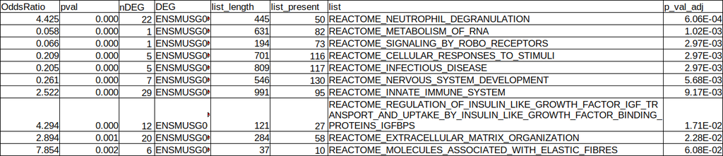

Finding pathways *significantly depleted* in DEGs (Odds Ratio <1) is quite normal considering that in each cluster we are examining just a fraction of the genome. Of the 9 gene sets with an adjusted p-value < 0.05, four of them have a significant enrichment in differentially expressed genes (Odds Ratio > 1):

- REACTOME: NEUTROPHIL DEGRANULATION
- REACTOME: INNATE IMMUNE SYSTEM
- REACTOME: REGULATION OF INSULIN LIKE GROWTH FACTOR IGF TRANSPORT AND UPTAKE BY INSULIN LIKE GROWTH FACTOR BINDING PROTEINS IGFBPS
- REACTOME: EXTRACELLULAR MATRIX ORGANIZATION

For example, of the 121 genes included in the pathway “REACTOME: EGULATION OF INSULIN LIKE GROWTH FACTOR…”, only 27 have been detected with some consistency in cluster 0, but of those 27, nearly half of them change significantly between the two diet conditions.

Plotting the top 10 pathway genesets for cluster 0 we can also gather how many of those 12 genes are up-regulated by a high fat diet or the other way around:

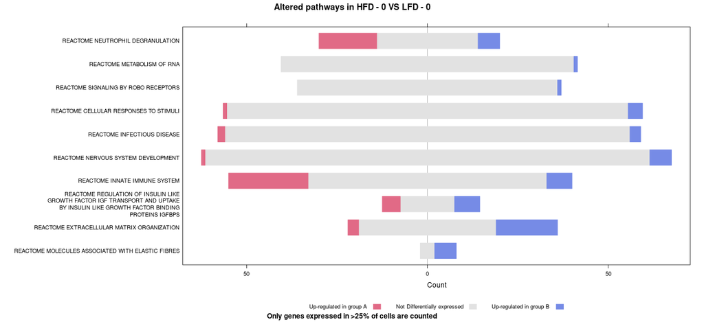

Obesity is strongly linked to mild chronic inflammation and alterations in insulin-driven metabolism, so results like this fall within what’s expected. From this point onward we could research each particular gene differentially expressed to see how that differential expression fits within the pathway and the study at large, but that’s usually a task better suited for people with extensive knowledge on the biological context´ being examined.